# Project1 Presentation

Yixiao Dong

10/7/2019

# Background

UMD(Urban Ministries of Durham) is a non-profit orgnization which connects with the community to end homelessness and fight poverty. This project is designed to dig into the data provided by UMD and find something valuable for the staff who are working for the orgnization.

# Raw Data

The data is provided by UMD which recorded the aids they give to people in need in the past years. The raw data sources file(“UMD_Services_Provided_20190719.tsv”) is given in the data folder. The file mainly includes the following information

- Date
- Client File Number: Client identifier (individual or family)
- Client File Merge: Separate files created for one family are merged together
- Bus Tickets: The service discontinued
- Notes of Service
- Food Provided for: Number of people in the family for which food was provided
- Food Pounds
- Clothing Items
- Diapers
- School Kits
- Hygiene Kits
- Financial Support: Money provided to clients. Service discontinued.

# Goal

In this project, imagine when a client come for help, I want to predict whether he will come again based on the aid he get in this visit and the imformation about his previous visits (if he visited before). In the way, we can pay more attention to the people who is likely to come again because they may need more help.

# Procedure

- data exploration
- data process
- classification model

# Data exploration

#### Time

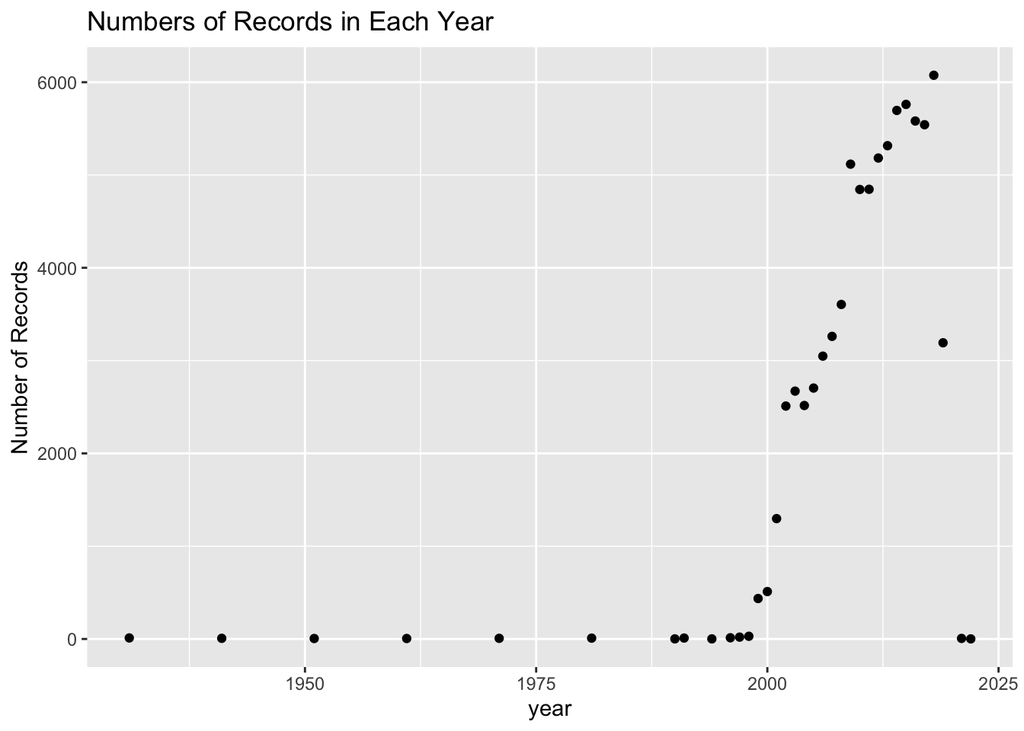

[figure not shown]

#### Type of Service

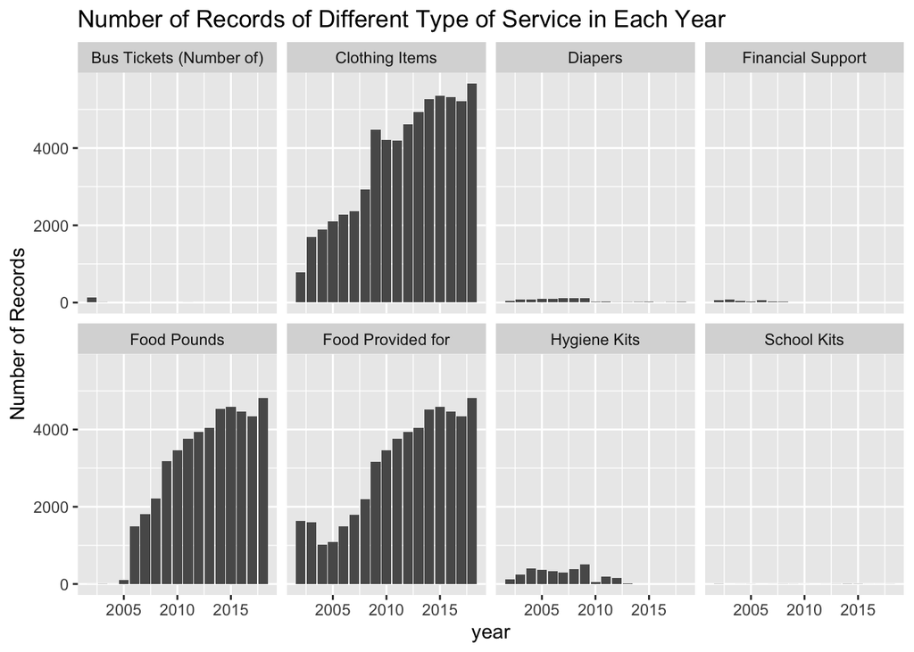

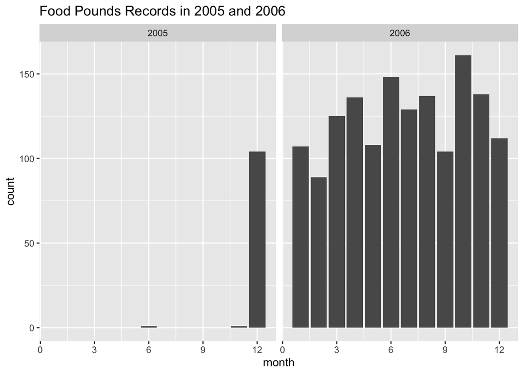

# Data Processing

1. Select data from 2005.12 to 2019.7
2. Select “Food Provided for”, “Food Pounds”, “Clothing Items”
3. Fill Na with 0
4. Merge “Client file Number” and “Client file Merge”
5. Add “Come Again”: 0 means not visit again, 1 means visit again
6. Compute and add: “Number of Visits before”, “Days Since Last Visit”
7. Compure and add: “Avg Food Provided For Before”, “Avg Food Pounds Before”, “Avg Clothing Items Before”
8. Save the dataset.

# Classification Model

In this project, I use XGBoost Model.

#### read data

The data used in prediction model includes following columns:

- Come Again
- Food Provided For
- Food Pounds
- Clothing Items
- Number of Visits Before
- Days Since last Visit
- Avg Food Provided For Before
- Avg Food Pounds Before
- Avg Clothing Items Before

```r
df <- read.csv("/Users/Yixiao/Desktop/611project/project_1/data/data.csv")
df$Come.Again <- as.factor(df$Come.Again)
df <- select(df, -year, -month, -day, -`Client.File.Number`)
df <- df[,c(4,1:3,5:9)]
```

#### split train data and test data

```r
set.seed(0)
train_i <- createDataPartition(df$Food.Provided.for, p=0.8, list=FALSE)
train_df <- df[train_i,]
test_df <- df[-train_i,]
```

#### train data is unbalanced

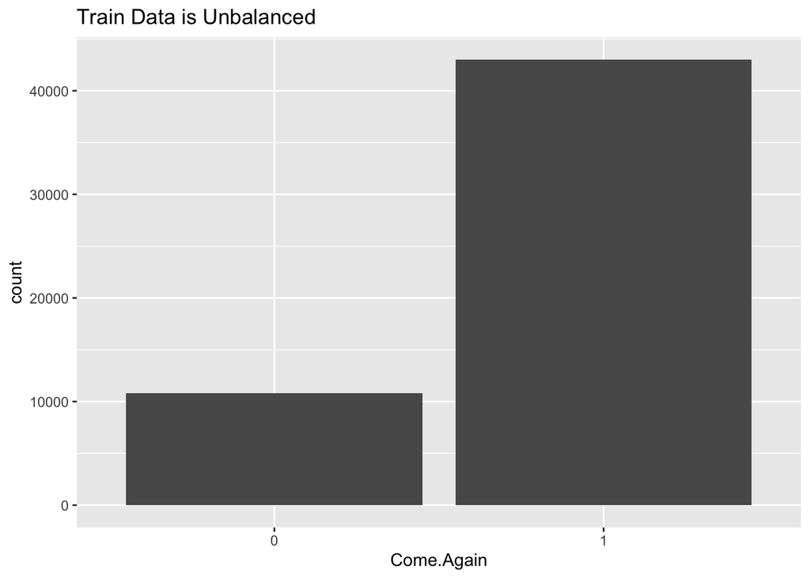

```r
count_train_df <- train_df %>% group_by(Come.Again) %>% summarise(count=n())
ggplot(count_train_df)+
  geom_bar(aes(Come.Again,count), stat = "identity") +
    labs(title = "Train Data is Unbalanced")
```

#### reconstruct train data by over-sampling

```r
train_df0 <- filter(train_df, Come.Again==0)
train_df1 <- filter(train_df, Come.Again==1)
train_df <- rbind(train_df0, train_df0, train_df0, train_df0, train_df1)
```

#### split train and test data into label and features

```r
train_label <- train_df %>% select(`Come.Again`) %>% as.matrix()
train_feature <- train_df %>% select(-`Come.Again`) %>% as.matrix()
test_label <- test_df %>% select(`Come.Again`) %>% as.matrix()
test_feature <- test_df %>% select(-`Come.Again`) %>% as.matrix()
```

#### train xgboost model

```r
xgb <- xgboost(data = train_feature,
               label = train_label,
               max_depth = 5,
               nround = 2000,
               subsample = 0.8,
               colsample_bytree = 0.5,
               eval_metric = "logloss",
               objective = "binary:logistic"
)
```

#### predict function returns a probablity in (0,1)

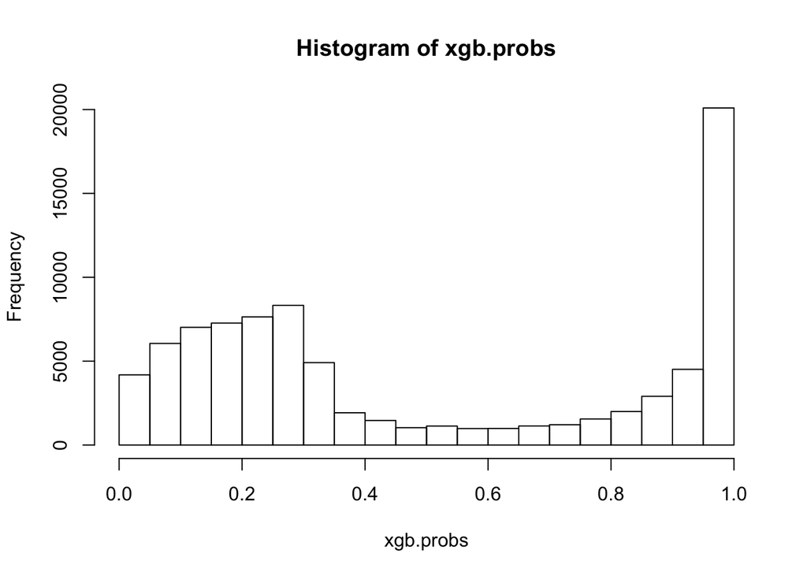

```r
xgb.probs = predict(xgb , train_feature)
hist(xgb.probs)
```